# 1. Einführung: Forschungsfragen und Daten

### 0.0.1 Lernziele und Literatur

Die Studierenden lernen empirische Gesundheitsökonomik als angewandte Data Science kennen, deren wichtigstes Ziel die Identifikation von kausalen Zusammenhängen aus Beobachtungsdaten ist (real-life evidence). Sie können unterschiedliche Datentypen und Studiendesigns zur Gewinnung von kausalen Aussagen unterscheiden.

##### 0.0.1.0.1 Literatur

- Stock & Watson, *Introduction to Econometrics*, Kapitel 1

### 0.0.2 Forschungsfragen

In der empirischen Gesundheitsökonomik untersuchen wir quantitative Fragen, auf die wir versuchen, quantitative Antworten zu finden. Beispiele für solche Fragen sind:

- Wie stark hängt die Inanspruchnahme ärztlicher Leistungen vom Umfang des Krankenversicherungsschutzes ab?
- Wie stark vermindert eine Erhöhung der Tabaksteuer den Zigarettenkonsum? Wie stark beeinflusst dies die Wahrscheinlichkeit, mit der Jugendliche anfangen zu rauchen?
- Es ist bekannt, dass die Gesundheit mit dem sozio-ökonomischen Status der Menschen zusammenhängt. Kann durch mehr Schulbildung die Bevölkerung gesünder werden?
- Wie gefährlich ist Alkoholkonsum im jungen Erwachsenenalter für die Gesundheit?
- Wieviele Menschenleben konnten durch die Einführung der Gurtpflicht in Autos gerettet werden?

Antworten auf diese und ähnliche Fragen sind wichtig, wenn eine Gesellschaft effektive und effiziente Maßnahmen zur Verbesserung der Gesundheit der Bevölkerung oder zur Senkung der Gesundheitsausgaben ohne Verschlechterung der Gesundheit ergreifen will. Diese Antworten zu finden ist Aufgabe der empirischen Gesundheitsökonomik. Dabei bedient sie sich verschiedener Datenquellen von kleinen Experimenten bis hin zu Big Data:

- Systematische Beobachtungen
- Befragungen (Personen, Haushalte, Unternehmen)
- Experimente (Hörsaal, Labor, reale Entscheidungen)
- Amtliche Statistik (VGR, Außenhandelsstatistik, Bundesagentur für Arbeit, etc.)
- Sonstige administrative Daten (DRG-Statistik, Abrechnungsdaten der Krankenversicherungen, etc.)

Die Daten werden mittels statistischer Methoden rechnergestützt analysiert. Kurz: Empirische Gesundheitsökonomik ist angewandte Data Science. Dabei gibt es unterschiedliche Analyseziele.

- **Beschreibung**: wird von der Politik benötigt um festzustellen, ob es aktuellen gesundheitspolitischen Handlungsbedarf gibt.
- **Prognose**: wird von der Politik benötigt um festzustellen, ob es zukünftigen gesundheitspolitischen Handlungsbedarf gibt.
- **Kausalanalyse**: darunter versteht man die Analyse von Ursache-Wirkungs-Zusammenhängen. Diese wird von der Politik benötigt um festzustellen, welche gesundheitspolitischen Maßnahmen erfolgversprechen sind.

Ein Schwerpunkt des Moduls “Empirische Gesundheitsökonomik” ist die **Kausalanalyse**. Sie beantwortet die Frage: **Was wäre, wenn…**. Der Goldstandard bei der Beantwortung kausaler Fragen sind **randomisierte Studien** (Randomized controlled trials oder RCTs). Diese liefern uns **Experimentaldaten**. Das bekannteste Beispiel für eine randomisierte Studie in der Gesundheitsökonomik ist das Rand Health Insurance Experiment. Leider lassen sich viele interessante und wichtige Fragen aus ethischen oder finanziellen Gründen nicht mit RCTs beantworten. Beispiel: Welchen Einfluss hat Rauchen während der Schwangerschaft auf Intelligenz und Bildungsergebnisse von Kindern? Solche Fragen müssen mit Hilfe sogenannter **Beobachtungsdaten** (neuerdings auch als **real-life evidence** bezeichnet) beantwortet werden, also Daten die durch Beobachtung im Alltag stattfindender Ereignisse statt aus Experimenten gewonnen werden. Der wesentliche Unterschied zu Experimentaldaten ist, dass der Forscher oder Analyst die Einteilung in **Versuchs- und Kontrollgruppen** nicht selbst vornehmen kann, sondern dass die Beteiligten in der Regel selbst wählen können. Im Beispiel entscheiden die werdenden Mütter selbst, ob sie während der Schwangerschaft rauchen wollen oder nicht.

Das wichtigste statistische Instrument der Kausalanalyse ist die **Regressionsanalyse**. Das praktische Einüben von Regressionanalyse und ihrer Interpretation im Kontext angewandter gesundheitspolitischer Fragen bildet daher den Schwerpunkt in der ersten Hälfte des Moduls “Empirische Gesundheitsökonomik”.

Die folgende Abbildung stammt aus einer gut gemachten Studie der empirischen Gesundheitsökonomik auf Basis von Beobachtungsdaten (Card et al. (2009): Does Medicare Save Lives? *Quarterly Journal of Economics* 124(2): 597-636). Die Studie versucht, den Einfluss von Krankenversicherungsschutz auf die Nachfrage nach medizinischen Leistungen zu bestimmen. Die Abbildung zeigt die relative Häufigkeit von Krankenhausaufenthalten in Kalifornien in Abhängigkeit vom Alter. Auf den ersten Blick fällt der Sprung bei 65 Jahren auf. Dies ist das Alter, ab dem US-Amerikaner Anspruch auf Medicare – die staatliche Krankenversicherung für Alte – haben. Mit dem Alter von 65 Jahren steigt die Anzahl krankenversicherter Amerikaner von 80 auf 100 Prozent an. Gleichzeitig steigt die Zahl der Krankenhausaufenthalte sprunghaft an. Nimmt man zugleich an, dass die Gesundheit mit dem Alter zwar schlechter wird, aber nicht sprunghaft, dann kann man aus der Abbildung bzw. einer analogen Regressionsanalyse zeigen, wie stark die Inanspruchnahme medizinischer Leistungen durch Krankenversicherung steigt.

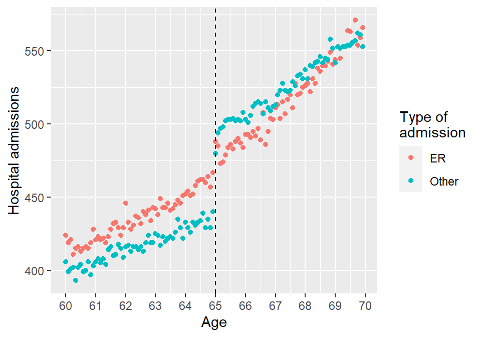

Das Verständnis von Abbildungen wie diesen, der ihnen zugrundeliegenden Logik und die Interpretation des Ergebnisses im Rahmen gesundheitsökomischer Theorie gehört zu den grundlegenden Kompetenzen forschender Gesundheitsökonomen.

### 0.0.3 Datentypen

Die für Untersuchungen der empirischen Gesundheitsökonomik herangezogenen Daten können u.a. entlang zweier Dimensionen unterschieden werden: der Anzahl der Beobachtungseinheiten (Personen, Haushalte, Firmen, Krankenhäuser, Schulen, Regionen, Länder) und der Anzahl der Zeitpunkte oder -räume (Stunden, Tage, Monate, Jahre),

1. Von **Querschnittsdaten** redet man, wenn Daten mehrerer Beobachtungseinheiten zu einem Zeitpunkt oder aus einem Zeitraum vorliegen.
2. Von einer **Zeitreihe** redet man, wenn Daten einer Beobachtungseinheit zu mehreren Zeitpunkten vorliegen.
3. Von **Panel-** oder **Längsschnittdaten** spricht man, wenn Daten mehrerer Beobachtungseinheiten zu mehreren Zeitpunkten vorliegen.

Wir geben nun für jeden Datentyp ein Beipiel und zeigen typische Darstellungen der Daten in Tabellenform und in Graphiken. Alle Graphiken werden mit ggplot erstellt. *Hinweis:* Im Skript zur Vorlesung “Empirische Gesundheitsökonomik” wird häufig auf Graphiken zur Verdeutlichung von Methoden und Daten zurückgegriffen. Dabei wird fast immer der entsprechende R-Code mit angegeben, so dass die Erstellung dieser Graphiken nachvollziehbar ist.

#### 0.0.3.1 Querschnittsdaten

In den 1880er Jahren erforschte Francis Galton die Vererbbarkeit menschlicher Eigenschaften. Als Teil dieser Arbeit sammelte er Daten zur Größe erwachsener Kinder und deren Eltern. Die von Galton gesammelten Daten sind als Übungsdatensatz “Galton” im R-package `mosaicData` verfügbar. Eine nützliche Eigenschaft von R und R-Packages ist die leichte Verfügbarkeit von Daten (meist als Dataframes) zu Übungszwecken. Diese Datensätze können mit der Funktion `data()` geladen werden. Eine Liste der Daten in einem Paket kann man mit – als Beispiel – `data(package = "mosaicData")` erhalten.

```r
data(Galton, package = "mosaicData")
head(Galton)
```

```
## # A tibble: 6 x 6
##   family father mother sex   height nkids
##   <fct>   <dbl>  <dbl> <fct>  <dbl> <int>
## 1 1        78.5   67   M       73.2     4
## 2 1        78.5   67   F       69.2     4
## 3 1        78.5   67   F       69       4
## 4 1        78.5   67   F       69       4
## 5 2        75.5   66.5 M       73.5     4
## 6 2        75.5   66.5 M       72.5     4
```

Der Datensatz enthält für jede Beobachtung (Person) das Geschlecht (`sex`), die Größe in Zoll (`height`), die Größe des Vaters (`father`) und der Mutter (`mother`), eine Ordnungszahl für die Familie (`family`) und die Anzahl der Kinder der Familie (`nkids`). Die Famile mit der Nummer 1 hat vier Kinder, einen Sohn und drei Töchter. Der Vater ist 78.5 Zoll groß, die Mutter 67 Zoll. Ein Zoll entspricht 2.54cm. der Sohn ist 73.2 Zoll groß, die Töchter 69.2 bzw. 69 Zoll. Von der zweiten Familie sehen wir nur die ersten beiden Kinder.

Galton war u.a. am Zusammenhang zwischen der Größe des Vaters und der Größe der Kinder nach Geschlecht interessiert. Beispiel für die Darstellung R:

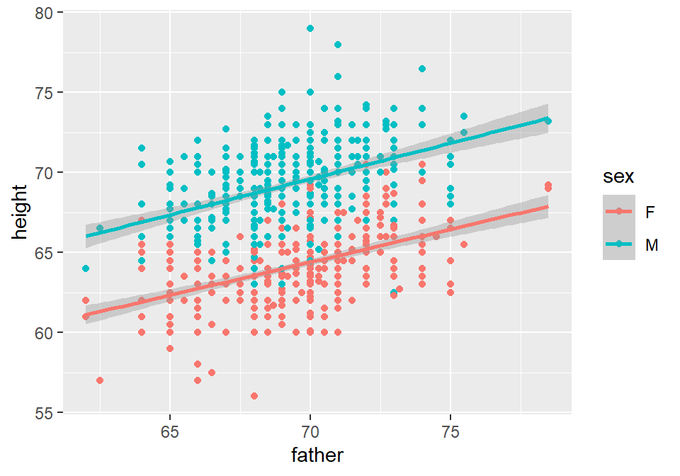

```r
ggplot(Galton, aes(x = father, y = height, color = sex)) +
  geom_point() + geom_smooth(method = "lm")
```

Die Abbildung zeigt – wenig überraschend – dass große Väter tendenziell große Söhne und Töchter haben. Die Regressionsgerade zeigt dabei einen Schätzwert für die mittlere Größe der Kinder für jede Größe des Vaters an. Konzentrieren wir uns nur auf die Söhne: wer genau hinschaut, wird feststellen, dass die Söhne eines 75 Zoll großen Vaters im Schnitt *kleiner* sind als 75 Zoll, und die Söhne eines 65 Zoll großen Vaters im Schnitt *größer* sind als 65 Zoll. Galton hat daraus geschlossen, dass sich die Größe in einer Familie (oder andere vererbbare Eigenschaften) von Generation zu Generation in Richtung der mittleren Größe in der Bevölkerung bewegt. Dieses Phänomen wurde von Galton “Regression to the Mean”, also Rückschritt hin zum Mittelwert genannt. Dies stellt den Ursprung des Begriffs Regressionsanalyse dar.

#### 0.0.3.2 Zeitreihen

Als Beispiel für eine **Zeitreihe** verwenden wir die Anzahl aller Geburten in den USA an jedem Tag des Jahres 1978. Der Datensatz `Births78` ist ebenfalls im package `mosaicData` enthalten.

```r
data(Births78, package = "mosaicData")
head(Births78)
```

```
## # A tibble: 6 x 8
##   date       births wday   year month day_of_year day_of_month day_of_week
##   <date>      <int> <ord> <dbl> <dbl>       <int>        <int>       <dbl>
## 1 1978-01-01   7701 Sun    1978     1           1            1           1
## 2 1978-01-02   7527 Mon    1978     1           2            2           2
## 3 1978-01-03   8825 Tue    1978     1           3            3           3
## 4 1978-01-04   8859 Wed    1978     1           4            4           4
## 5 1978-01-05   9043 Thu    1978     1           5            5           5
## 6 1978-01-06   9208 Fri    1978     1           6            6           6
```

Der Datensatz enthält das Datum im Format Jahr-Monat-Tag, die Anzahl an Geburten, den Tag des Jahres und den Wochentag. Eine Zeitreihe wird naturgemäß mit der Zeit an der x-Achse dargestellt, wobei wir hier nur die letzten 90 Tage des Jahres zeigen:

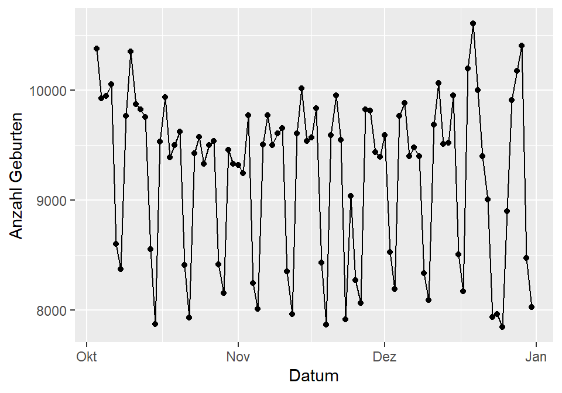

```r
ggplot(data = filter(Births78, day_of_year >= 276)) +
  geom_point(aes(x = date, y = births)) +
  geom_line(aes(x = date, y = births)) +
  labs(y = "Anzahl Geburten", x = "Datum")
```

Bei der graphischen Darstellung fallen sofort die starken Schwankungen in der Zahl der Geburten auf. Bei genauerer Betrachtung wird man feststellen, dass Samstage und insbesondere Sonntage als Geburtstage weniger beliebt sind. Darüber hinaus findet man in den Daten noch Sondereffekte von Weihnachten und Thanksgiving (23.11.). Die Erklärung ist natürlich, das *geplante* Kaiserschnitte selten an Sonn- und Feiertagen durchgeführt werden. Auch Ärzte wollen mal frei haben! Fasst man die Daten in Form von Boxplots nach Wochentag mit R zusammen, ergibt sich folgendes Bild:

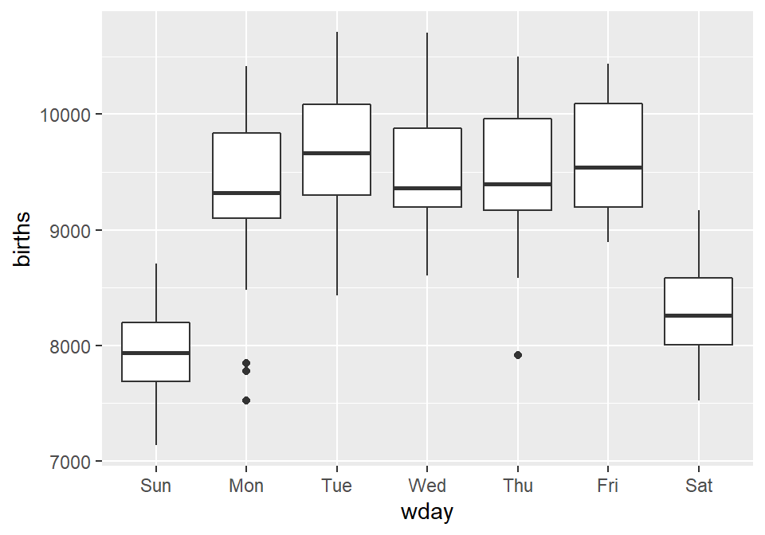

```r
Births78 %>% ggplot(aes(x = wday, y = births)) + geom_boxplot()
```

Da es sich um amerikanische Daten handelt, wird der Sonntag als erster Tag der Woche dargestellt. Dies kann man bei Bedarf natürlich ändern, so dass Montag der erste Wochentag ist.

#### 0.0.3.3 Paneldaten

Unter **Paneldaten** versteht man die Daten, die sowohl eine Querschnitts- als auch eine Längsschnittsdimension aufweisen. Im Package `mosaicData` befindet sich als Beispiel der Datensatz `Birthdays`, der sehr umfassend ist und die Anzahl an Geburten in jedem Bundesstaat der USA an jedem Tag zwischen 1969 und 1988 enthält. Die Querschnittsdimension (Beobachtungs*einheiten*) sind hier die Bundesstaaten, die Längsschnittdimension ist natürlich die Zeit.

```r
data(Birthdays, package = "mosaicData")
head(Birthdays)
```

```
## # A tibble: 6 x 7
##   state  year month   day date                wday  births
##   <chr> <int> <int> <int> <dttm>              <ord>  <int>
## 1 AK     1969     1     1 1969-01-01 00:00:00 Wed       14
## 2 AL     1969     1     1 1969-01-01 00:00:00 Wed      174
## 3 AR     1969     1     1 1969-01-01 00:00:00 Wed       78
## 4 AZ     1969     1     1 1969-01-01 00:00:00 Wed       84
## 5 CA     1969     1     1 1969-01-01 00:00:00 Wed      824
## 6 CO     1969     1     1 1969-01-01 00:00:00 Wed      100
```

```r
tail(Birthdays)
```

```
## # A tibble: 6 x 7
##   state  year month   day date                wday  births
##   <chr> <int> <int> <int> <dttm>              <ord>  <int>
## 1 VA     1988    12    31 1988-12-31 00:00:00 Sat      201
## 2 VT     1988    12    31 1988-12-31 00:00:00 Sat       21
## 3 WA     1988    12    31 1988-12-31 00:00:00 Sat      157
## 4 WI     1988    12    31 1988-12-31 00:00:00 Sat      167
## 5 WV     1988    12    31 1988-12-31 00:00:00 Sat       45
## 6 WY     1988    12    31 1988-12-31 00:00:00 Sat       18
```

Der Paneldatensatz hat insgesamt 51 mal 365 mal 20 Beobachtungen (plus ein paar mehr für Schaltjahre), da die USA einschl. Washington DC 51 Bundesstaaten haben, das Jahr 365 Tage hat, und Daten für 20 Jahre vorliegen. Das sind über 370,000 Beobachtungen! Die Abmessungen eines Datensatzes erhält man z.B. mit `str()` oder einfach `dim()`, wobei die erste Zahl die Anzahl an Zeilen und die zweite Zahl die Anzahl an Spalten eines Objekts angibt:

```r
str(Birthdays)
```

```
## 'data.frame':    372864 obs. of  7 variables:
##  $ state : chr  "AK" "AL" "AR" "AZ" ...
##  $ year  : int  1969 1969 1969 1969 1969 1969 1969 1969 1969 1969 ...
##  $ month : int  1 1 1 1 1 1 1 1 1 1 ...
##  $ day   : int  1 1 1 1 1 1 1 1 1 1 ...
##  $ date  : POSIXct, format: "1969-01-01" "1969-01-01" ...
##  $ wday  : Ord.factor w/ 7 levels "Sun"<"Mon"<"Tues"<..: 4 4 4 4 4 4 4 4 4 4 ...
##  $ births: int  14 174 78 84 824 100 90 88 32 288 ...
```

```r
dim(Birthdays)
```

```
## [1] 372864      7
```

Die Abmessungen werden aber auch einfach im “Environment”-Fenster angezeigt, sobald ein Datensatz geladen ist. Wir suchen nun die Bundesstaaten Kalifornien, Texas, New York und Florida als bevölkerungsreichste Bundesstaaten der USA heraus und zeigen exemplarisch die Zahl der Geburten am 24. März jeden Jahres von 1969 bis 1988.

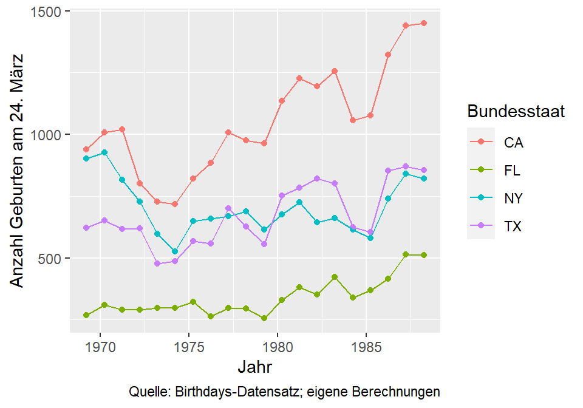

Geburten am 24. März in vier Bundesstaaten

```r
Auswahl <- filter(Birthdays, state %in% c("CA", "TX", "NY", "FL") &
                    month == 3 & day == 24)
ggplot(data = Auswahl, aes(x = date, y = births, color = state)) +
  geom_point() +
  geom_line() +
  labs(y = "Anzahl Geburten am 24. März",
       x = "Jahr",
       color = "Bundesstaat",
       # title = "Geburten am 24. März in vier Bundesstaaten",
       caption = "Quelle: Birthdays-Datensatz; eigene Berechnungen")
```

Bei der Ästhethik `aes()` haben wir nun zusätzlich `color = state` angegeben. Dies bedeutet, dass die die Punkte und Striche nach Bundesstaat unterschiedliche Farben haben sollen. Eine alternative Darstellung der gleichen Zahlen in vier verschiedenen Koordinatensystemen erhält man durch `facet_wrap()`:

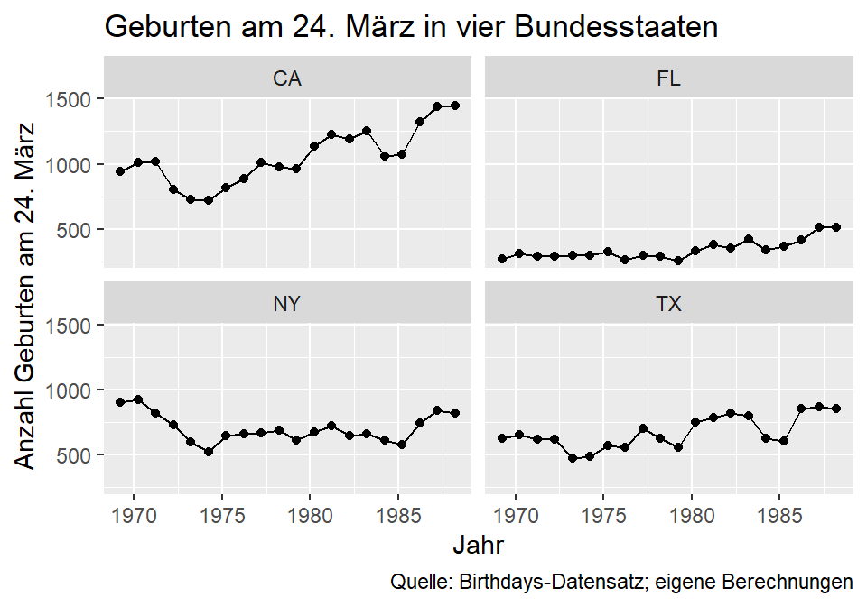

```r
ggplot(data = Auswahl) +
  geom_point( aes(x = date, y = births)) +
  geom_line( aes(x = date, y = births)) +
  facet_wrap( ~ state) +
  labs(y = "Anzahl Geburten am 24. März",
       x = "Jahr",
       title = "Geburten am 24. März in vier Bundesstaaten",
       caption = "Quelle: Birthdays-Datensatz; eigene Berechnungen")
```

Nun hat der hier als Beispiel verwendete Panel-Datensatz eine große Anzahl an Beobachtungen $T$ in der Dimension Zeit (Tage über 20 Jahre hinweg), aber eine vergleichsweise kleine Anzahl $N$ an Beobachtungseinheiten (US-Bundesstaaten). Eine andere typische Art von Paneldaten hat umgekehrt großes $N$ und kleines $T$, d.h. sehr viele Beobachtungseinheiten, die über wenige Zeitpunkte hinweg beobachtet werden. Betrachten wir als Beispiel einen Auszug aus der Panel Study of Income Dynamics (PSID), einer großen amerikanischen Panelstudie:

```r
data(PSID7682, package = "AER")
dim(PSID7682)
```

```
## [1] 4165   14
```

```r
PSID7682 %>% count(year)
```

```
## # A tibble: 7 x 2
##   year      n
##   <fct> <int>
## 1 1976    595
## 2 1977    595
## 3 1978    595
## 4 1979    595
## 5 1980    595
## 6 1981    595
## 7 1982    595
```

Der Datensatz hat 4165 Zeilen (Beobachungen) und 14 Variablen (Spalten). Dabei gibt es in jedem Jahr von 1976 bis 1982 Daten zu 595 unterschiedlichen Personen.

### 0.0.4 Wiederholungsfragen

Geben Sie an, ob die Aussage wahr oder falsch ist, und begründen Sie Ihre Antwort. Beziehen Sie sich dabei auf Inhalte des Kapitels, und nennen Sie zusätzliche Annahmen, die Sie möglicherweise treffen müssen.

1. Ein gutes Beispiel für Querschnittsdaten ist die tägliche Anzahl der Geburten in einem Land in einem Jahr.
2. Die Regressionsanalyse hat ihren Namen von Charles Darwin bekommen, der damit den Rückschritt einzelner Arten unter evolutionärem Druck beschreibt.
3. Der Goldstandard bei der “Was wäre wenn”-Analyse ist die Lineare Regression.
4. Zur Darstellung der Entwicklung der durchschnittlichen Krankenhaus-Liegezeiten in den europäischen Ländern seit Einführung der DRGs benötigt man Panel-Daten.